# Risk Factor Analysis

## Outcome Variable

**Outcome Variable:** ever_co

## Predictor Variables

**Intervention Variable:** mbmi

**Adjustment Set:**

- arm
- W_mage
- meducyrs
- feducyrs
- single
- brthmon
- delta_W_mage
- delta_meducyrs
- delta_feducyrs
- delta_single
- delta_brthmon

## Stratifying Variables

The analysis was stratified on these variable(s):

- agecat
- studyid
- country

## Data Summary

| agecat | studyid | country | mbmi | ever_co | n_cell | n |
| --- | --- | --- | --- | --- | --- | --- |
| 0-24 months | ki0047075b-MAL-ED | BANGLADESH | Normal weight | 0 | 194 | 254 |
| 0-24 months | ki0047075b-MAL-ED | BANGLADESH | Normal weight | 1 | 28 | 254 |
| 0-24 months | ki0047075b-MAL-ED | BANGLADESH | Underweight | 0 | 21 | 254 |
| 0-24 months | ki0047075b-MAL-ED | BANGLADESH | Underweight | 1 | 11 | 254 |
| 0-24 months | ki0047075b-MAL-ED | BRAZIL | Normal weight | 0 | 209 | 221 |
| 0-24 months | ki0047075b-MAL-ED | BRAZIL | Normal weight | 1 | 2 | 221 |
| 0-24 months | ki0047075b-MAL-ED | BRAZIL | Underweight | 0 | 10 | 221 |
| 0-24 months | ki0047075b-MAL-ED | BRAZIL | Underweight | 1 | 0 | 221 |
| 0-24 months | ki0047075b-MAL-ED | INDIA | Normal weight | 0 | 154 | 242 |
| 0-24 months | ki0047075b-MAL-ED | INDIA | Normal weight | 1 | 39 | 242 |
| 0-24 months | ki0047075b-MAL-ED | INDIA | Underweight | 0 | 35 | 242 |
| 0-24 months | ki0047075b-MAL-ED | INDIA | Underweight | 1 | 14 | 242 |
| 0-24 months | ki0047075b-MAL-ED | NEPAL | Normal weight | 0 | 217 | 238 |
| 0-24 months | ki0047075b-MAL-ED | NEPAL | Normal weight | 1 | 21 | 238 |
| 0-24 months | ki0047075b-MAL-ED | NEPAL | Underweight | 0 | 0 | 238 |
| 0-24 months | ki0047075b-MAL-ED | NEPAL | Underweight | 1 | 0 | 238 |
| 0-24 months | ki0047075b-MAL-ED | PERU | Normal weight | 0 | 275 | 290 |
| 0-24 months | ki0047075b-MAL-ED | PERU | Normal weight | 1 | 10 | 290 |
| 0-24 months | ki0047075b-MAL-ED | PERU | Underweight | 0 | 3 | 290 |
| 0-24 months | ki0047075b-MAL-ED | PERU | Underweight | 1 | 2 | 290 |
| 0-24 months | ki0047075b-MAL-ED | SOUTH AFRICA | Normal weight | 0 | 242 | 270 |
| 0-24 months | ki0047075b-MAL-ED | SOUTH AFRICA | Normal weight | 1 | 20 | 270 |
| 0-24 months | ki0047075b-MAL-ED | SOUTH AFRICA | Underweight | 0 | 8 | 270 |
| 0-24 months | ki0047075b-MAL-ED | SOUTH AFRICA | Underweight | 1 | 0 | 270 |
| 0-24 months | ki0047075b-MAL-ED | TANZANIA, UNITED REPUBLIC OF | Normal weight | 0 | 222 | 256 |
| 0-24 months | ki0047075b-MAL-ED | TANZANIA, UNITED REPUBLIC OF | Normal weight | 1 | 20 | 256 |
| 0-24 months | ki0047075b-MAL-ED | TANZANIA, UNITED REPUBLIC OF | Underweight | 0 | 11 | 256 |
| 0-24 months | ki0047075b-MAL-ED | TANZANIA, UNITED REPUBLIC OF | Underweight | 1 | 3 | 256 |
| 0-24 months | ki1000304b-SAS-CompFeed | INDIA | Normal weight | 0 | 843 | 1389 |
| 0-24 months | ki1000304b-SAS-CompFeed | INDIA | Normal weight | 1 | 199 | 1389 |

[output cut: 158 more lines]

The following strata were considered:

- agecat: 0-24 months, studyid: ki0047075b-MAL-ED, country: BANGLADESH
- agecat: 0-24 months, studyid: ki0047075b-MAL-ED, country: BRAZIL
- agecat: 0-24 months, studyid: ki0047075b-MAL-ED, country: INDIA
- agecat: 0-24 months, studyid: ki0047075b-MAL-ED, country: NEPAL
- agecat: 0-24 months, studyid: ki0047075b-MAL-ED, country: PERU
- agecat: 0-24 months, studyid: ki0047075b-MAL-ED, country: SOUTH AFRICA
- agecat: 0-24 months, studyid: ki0047075b-MAL-ED, country: TANZANIA, UNITED REPUBLIC OF
- agecat: 0-24 months, studyid: ki1000304b-SAS-CompFeed, country: INDIA
- agecat: 0-24 months, studyid: ki1017093-NIH-Birth, country: BANGLADESH
- agecat: 0-24 months, studyid: ki1017093b-PROVIDE, country: BANGLADESH
- agecat: 0-24 months, studyid: ki1017093c-NIH-Crypto, country: BANGLADESH
- agecat: 0-24 months, studyid: ki1066203-TanzaniaChild2, country: TANZANIA, UNITED REPUBLIC OF
- agecat: 0-24 months, studyid: ki1112895-iLiNS-Zinc, country: BURKINA FASO
- agecat: 0-24 months, studyid: ki1119695-PROBIT, country: BELARUS
- agecat: 0-24 months, studyid: ki1126311-ZVITAMBO, country: ZIMBABWE
- agecat: 0-24 months, studyid: ki1148112-LCNI-5, country: MALAWI
- agecat: 0-6 months, studyid: ki0047075b-MAL-ED, country: BANGLADESH
- agecat: 0-6 months, studyid: ki0047075b-MAL-ED, country: BRAZIL
- agecat: 0-6 months, studyid: ki0047075b-MAL-ED, country: INDIA
- agecat: 0-6 months, studyid: ki0047075b-MAL-ED, country: NEPAL
- agecat: 0-6 months, studyid: ki0047075b-MAL-ED, country: PERU
- agecat: 0-6 months, studyid: ki0047075b-MAL-ED, country: SOUTH AFRICA
- agecat: 0-6 months, studyid: ki0047075b-MAL-ED, country: TANZANIA, UNITED REPUBLIC OF
- agecat: 0-6 months, studyid: ki1000304b-SAS-CompFeed, country: INDIA
- agecat: 0-6 months, studyid: ki1017093-NIH-Birth, country: BANGLADESH
- agecat: 0-6 months, studyid: ki1017093b-PROVIDE, country: BANGLADESH
- agecat: 0-6 months, studyid: ki1017093c-NIH-Crypto, country: BANGLADESH
- agecat: 0-6 months, studyid: ki1066203-TanzaniaChild2, country: TANZANIA, UNITED REPUBLIC OF
- agecat: 0-6 months, studyid: ki1119695-PROBIT, country: BELARUS
- agecat: 0-6 months, studyid: ki1126311-ZVITAMBO, country: ZIMBABWE
- agecat: 0-6 months, studyid: ki1148112-LCNI-5, country: MALAWI
- agecat: 6-24 months, studyid: ki0047075b-MAL-ED, country: BANGLADESH
- agecat: 6-24 months, studyid: ki0047075b-MAL-ED, country: BRAZIL
- agecat: 6-24 months, studyid: ki0047075b-MAL-ED, country: INDIA
- agecat: 6-24 months, studyid: ki0047075b-MAL-ED, country: NEPAL
- agecat: 6-24 months, studyid: ki0047075b-MAL-ED, country: PERU
- agecat: 6-24 months, studyid: ki0047075b-MAL-ED, country: SOUTH AFRICA
- agecat: 6-24 months, studyid: ki0047075b-MAL-ED, country: TANZANIA, UNITED REPUBLIC OF
- agecat: 6-24 months, studyid: ki1000304b-SAS-CompFeed, country: INDIA
- agecat: 6-24 months, studyid: ki1017093-NIH-Birth, country: BANGLADESH
- agecat: 6-24 months, studyid: ki1017093b-PROVIDE, country: BANGLADESH
- agecat: 6-24 months, studyid: ki1017093c-NIH-Crypto, country: BANGLADESH
- agecat: 6-24 months, studyid: ki1066203-TanzaniaChild2, country: TANZANIA, UNITED REPUBLIC OF
- agecat: 6-24 months, studyid: ki1112895-iLiNS-Zinc, country: BURKINA FASO
- agecat: 6-24 months, studyid: ki1119695-PROBIT, country: BELARUS
- agecat: 6-24 months, studyid: ki1126311-ZVITAMBO, country: ZIMBABWE
- agecat: 6-24 months, studyid: ki1148112-LCNI-5, country: MALAWI

### Dropped Strata

Some strata were dropped due to rare outcomes:

- agecat: 0-24 months, studyid: ki0047075b-MAL-ED, country: BRAZIL
- agecat: 0-24 months, studyid: ki0047075b-MAL-ED, country: NEPAL
- agecat: 0-24 months, studyid: ki0047075b-MAL-ED, country: PERU
- agecat: 0-24 months, studyid: ki0047075b-MAL-ED, country: SOUTH AFRICA
- agecat: 0-24 months, studyid: ki0047075b-MAL-ED, country: TANZANIA, UNITED REPUBLIC OF
- agecat: 0-24 months, studyid: ki1066203-TanzaniaChild2, country: TANZANIA, UNITED REPUBLIC OF
- agecat: 0-24 months, studyid: ki1119695-PROBIT, country: BELARUS
- agecat: 0-6 months, studyid: ki0047075b-MAL-ED, country: BANGLADESH
- agecat: 0-6 months, studyid: ki0047075b-MAL-ED, country: BRAZIL
- agecat: 0-6 months, studyid: ki0047075b-MAL-ED, country: INDIA
- agecat: 0-6 months, studyid: ki0047075b-MAL-ED, country: NEPAL
- agecat: 0-6 months, studyid: ki0047075b-MAL-ED, country: PERU
- agecat: 0-6 months, studyid: ki0047075b-MAL-ED, country: SOUTH AFRICA
- agecat: 0-6 months, studyid: ki0047075b-MAL-ED, country: TANZANIA, UNITED REPUBLIC OF
- agecat: 0-6 months, studyid: ki1017093c-NIH-Crypto, country: BANGLADESH
- agecat: 0-6 months, studyid: ki1066203-TanzaniaChild2, country: TANZANIA, UNITED REPUBLIC OF
- agecat: 0-6 months, studyid: ki1119695-PROBIT, country: BELARUS
- agecat: 0-6 months, studyid: ki1148112-LCNI-5, country: MALAWI
- agecat: 6-24 months, studyid: ki0047075b-MAL-ED, country: BRAZIL
- agecat: 6-24 months, studyid: ki0047075b-MAL-ED, country: NEPAL
- agecat: 6-24 months, studyid: ki0047075b-MAL-ED, country: PERU
- agecat: 6-24 months, studyid: ki0047075b-MAL-ED, country: SOUTH AFRICA
- agecat: 6-24 months, studyid: ki0047075b-MAL-ED, country: TANZANIA, UNITED REPUBLIC OF
- agecat: 6-24 months, studyid: ki1066203-TanzaniaChild2, country: TANZANIA, UNITED REPUBLIC OF
- agecat: 6-24 months, studyid: ki1119695-PROBIT, country: BELARUS

## Methods Detail

We’re interested in the causal parameters $E[Y_a]$ for all values of $a \in \mathcal{A}$. These parameters represent the mean outcome if, possibly contrary to fact, we intervened to set all units to have $A=a$. Under the randomization and positivity assumptions, these are identified by the statistical parameters $\psi_a=E_W[E_{Y|A,W}(Y|A=a,W)]$. In addition, we’re interested in the mean of $Y$, $E[Y]$ under no intervention (the observed mean). We will estimate these parameters by using SuperLearner to fit the relevant likelihood factors – $E_{Y|A,W}(Y|A=a,W)$ and $p(A=a|W)$, and then updating our likelihood fit using a joint TMLE.

For unadjusted analyses ($W=\{\}$), initial likelihoods were estimated using Lrnr_glm to estimate the simple $E(Y|A)$ and Lrnr_mean to estimate $p(A)$. For adjusted analyses, a small library containing Lrnr_glmnet, Lrnr_xgboost, and Lrnr_mean was used.

Having estimated these parameters, we will then use the delta method to estimate relative risks and attributable risks relative to a prespecified baseline level of $A$.

# Results Detail

## Results Plots

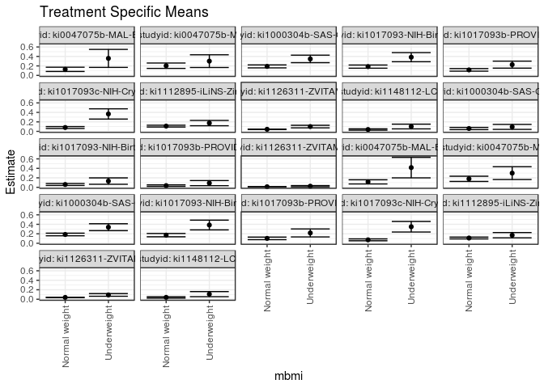

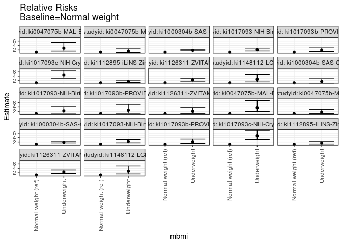

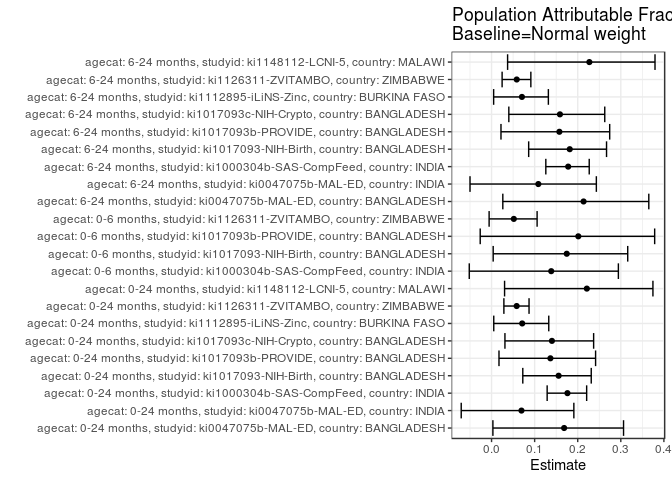

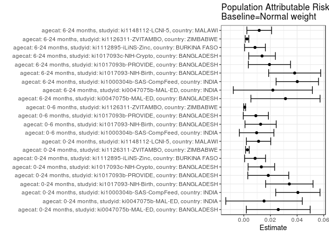

## Results Table

### Parameter: TSM

| agecat | studyid | country | intervention_level | baseline_level | estimate | ci_lower | ci_upper |
| --- | --- | --- | --- | --- | --- | --- | --- |
| 0-24 months | ki0047075b-MAL-ED | BANGLADESH | Normal weight | NA | 0.1276808 | 0.0830401 | 0.1723215 |
| 0-24 months | ki0047075b-MAL-ED | BANGLADESH | Underweight | NA | 0.3589575 | 0.1690572 | 0.5488578 |
| 0-24 months | ki0047075b-MAL-ED | INDIA | Normal weight | NA | 0.2038017 | 0.1470543 | 0.2605492 |
| 0-24 months | ki0047075b-MAL-ED | INDIA | Underweight | NA | 0.3007317 | 0.1665022 | 0.4349613 |
| 0-24 months | ki1000304b-SAS-CompFeed | INDIA | Normal weight | NA | 0.1897960 | 0.1586631 | 0.2209290 |
| 0-24 months | ki1000304b-SAS-CompFeed | INDIA | Underweight | NA | 0.3474467 | 0.2683919 | 0.4265016 |
| 0-24 months | ki1017093-NIH-Birth | BANGLADESH | Normal weight | NA | 0.1853736 | 0.1518697 | 0.2188774 |
| 0-24 months | ki1017093-NIH-Birth | BANGLADESH | Underweight | NA | 0.3839921 | 0.2878966 | 0.4800876 |
| 0-24 months | ki1017093b-PROVIDE | BANGLADESH | Normal weight | NA | 0.1161514 | 0.0888964 | 0.1434065 |
| 0-24 months | ki1017093b-PROVIDE | BANGLADESH | Underweight | NA | 0.2268064 | 0.1525981 | 0.3010147 |
| 0-24 months | ki1017093c-NIH-Crypto | BANGLADESH | Normal weight | NA | 0.0808617 | 0.0601743 | 0.1015491 |
| 0-24 months | ki1017093c-NIH-Crypto | BANGLADESH | Underweight | NA | 0.3669032 | 0.2588356 | 0.4749709 |
| 0-24 months | ki1112895-iLiNS-Zinc | BURKINA FASO | Normal weight | NA | 0.1108097 | 0.0916672 | 0.1299521 |
| 0-24 months | ki1112895-iLiNS-Zinc | BURKINA FASO | Underweight | NA | 0.1747762 | 0.1184407 | 0.2311118 |
| 0-24 months | ki1126311-ZVITAMBO | ZIMBABWE | Normal weight | NA | 0.0436499 | 0.0394882 | 0.0478116 |
| 0-24 months | ki1126311-ZVITAMBO | ZIMBABWE | Underweight | NA | 0.1010203 | 0.0740834 | 0.1279572 |
| 0-24 months | ki1148112-LCNI-5 | MALAWI | Normal weight | NA | 0.0390797 | 0.0246229 | 0.0535364 |
| 0-24 months | ki1148112-LCNI-5 | MALAWI | Underweight | NA | 0.1018843 | 0.0521282 | 0.1516405 |
| 0-6 months | ki1000304b-SAS-CompFeed | INDIA | Normal weight | NA | 0.0598853 | 0.0367321 | 0.0830385 |
| 0-6 months | ki1000304b-SAS-CompFeed | INDIA | Underweight | NA | 0.0943805 | 0.0418398 | 0.1469211 |
| 0-6 months | ki1017093-NIH-Birth | BANGLADESH | Normal weight | NA | 0.0597194 | 0.0392981 | 0.0801408 |
| 0-6 months | ki1017093-NIH-Birth | BANGLADESH | Underweight | NA | 0.1315278 | 0.0641495 | 0.1989061 |
| 0-6 months | ki1017093b-PROVIDE | BANGLADESH | Normal weight | NA | 0.0358122 | 0.0202106 | 0.0514139 |
| 0-6 months | ki1017093b-PROVIDE | BANGLADESH | Underweight | NA | 0.0885207 | 0.0346037 | 0.1424378 |
| 0-6 months | ki1126311-ZVITAMBO | ZIMBABWE | Normal weight | NA | 0.0117630 | 0.0095652 | 0.0139608 |
| 0-6 months | ki1126311-ZVITAMBO | ZIMBABWE | Underweight | NA | 0.0236506 | 0.0102867 | 0.0370146 |
| 6-24 months | ki0047075b-MAL-ED | BANGLADESH | Normal weight | NA | 0.1151628 | 0.0710225 | 0.1593031 |
| 6-24 months | ki0047075b-MAL-ED | BANGLADESH | Underweight | NA | 0.4162058 | 0.1991738 | 0.6332377 |
| 6-24 months | ki0047075b-MAL-ED | INDIA | Normal weight | NA | 0.1790421 | 0.1239047 | 0.2341795 |
| 6-24 months | ki0047075b-MAL-ED | INDIA | Underweight | NA | 0.2995518 | 0.1642968 | 0.4348068 |
| 6-24 months | ki1000304b-SAS-CompFeed | INDIA | Normal weight | NA | 0.1855588 | 0.1580093 | 0.2131084 |
| 6-24 months | ki1000304b-SAS-CompFeed | INDIA | Underweight | NA | 0.3392578 | 0.2664102 | 0.4121055 |
| 6-24 months | ki1017093-NIH-Birth | BANGLADESH | Normal weight | NA | 0.1721577 | 0.1371054 | 0.2072101 |
| 6-24 months | ki1017093-NIH-Birth | BANGLADESH | Underweight | NA | 0.3853339 | 0.2822959 | 0.4883718 |
| 6-24 months | ki1017093b-PROVIDE | BANGLADESH | Normal weight | NA | 0.1030875 | 0.0760695 | 0.1301056 |
| 6-24 months | ki1017093b-PROVIDE | BANGLADESH | Underweight | NA | 0.2179691 | 0.1339348 | 0.3020035 |
| 6-24 months | ki1017093c-NIH-Crypto | BANGLADESH | Normal weight | NA | 0.0726015 | 0.0526795 | 0.0925235 |
| 6-24 months | ki1017093c-NIH-Crypto | BANGLADESH | Underweight | NA | 0.3493893 | 0.2378834 | 0.4608952 |
| 6-24 months | ki1112895-iLiNS-Zinc | BURKINA FASO | Normal weight | NA | 0.1108818 | 0.0917325 | 0.1300312 |
| 6-24 months | ki1112895-iLiNS-Zinc | BURKINA FASO | Underweight | NA | 0.1703718 | 0.1146971 | 0.2260465 |
| 6-24 months | ki1126311-ZVITAMBO | ZIMBABWE | Normal weight | NA | 0.0387273 | 0.0345228 | 0.0429318 |
| 6-24 months | ki1126311-ZVITAMBO | ZIMBABWE | Underweight | NA | 0.0910435 | 0.0627764 | 0.1193107 |
| 6-24 months | ki1148112-LCNI-5 | MALAWI | Normal weight | NA | 0.0394477 | 0.0248205 | 0.0540749 |
| 6-24 months | ki1148112-LCNI-5 | MALAWI | Underweight | NA | 0.1077472 | 0.0540631 | 0.1614313 |

### Parameter: E(Y)

| agecat | studyid | country | intervention_level | baseline_level | estimate | ci_lower | ci_upper |
| --- | --- | --- | --- | --- | --- | --- | --- |
| 0-24 months | ki0047075b-MAL-ED | BANGLADESH | NA | NA | 0.1535433 | 0.1091205 | 0.1979661 |
| 0-24 months | ki0047075b-MAL-ED | INDIA | NA | NA | 0.2190083 | 0.1667935 | 0.2712230 |
| 0-24 months | ki1000304b-SAS-CompFeed | INDIA | NA | NA | 0.2303816 | 0.1859599 | 0.2748032 |
| 0-24 months | ki1017093-NIH-Birth | BANGLADESH | NA | NA | 0.2195513 | 0.1870467 | 0.2520558 |
| 0-24 months | ki1017093b-PROVIDE | BANGLADESH | NA | NA | 0.1345291 | 0.1086533 | 0.1604050 |
| 0-24 months | ki1017093c-NIH-Crypto | BANGLADESH | NA | NA | 0.0940397 | 0.0732057 | 0.1148737 |
| 0-24 months | ki1112895-iLiNS-Zinc | BURKINA FASO | NA | NA | 0.1192949 | 0.0996089 | 0.1389809 |
| 0-24 months | ki1126311-ZVITAMBO | ZIMBABWE | NA | NA | 0.0463502 | 0.0421864 | 0.0505140 |
| 0-24 months | ki1148112-LCNI-5 | MALAWI | NA | NA | 0.0501792 | 0.0353804 | 0.0649781 |
| 0-6 months | ki1000304b-SAS-CompFeed | INDIA | NA | NA | 0.0695148 | 0.0442283 | 0.0948014 |
| 0-6 months | ki1017093-NIH-Birth | BANGLADESH | NA | NA | 0.0723473 | 0.0519719 | 0.0927227 |
| 0-6 months | ki1017093b-PROVIDE | BANGLADESH | NA | NA | 0.0448430 | 0.0291486 | 0.0605375 |
| 0-6 months | ki1126311-ZVITAMBO | ZIMBABWE | NA | NA | 0.0124039 | 0.0102074 | 0.0146004 |
| 6-24 months | ki0047075b-MAL-ED | BANGLADESH | NA | NA | 0.1464435 | 0.1015265 | 0.1913605 |
| 6-24 months | ki0047075b-MAL-ED | INDIA | NA | NA | 0.2008547 | 0.1494120 | 0.2522974 |
| 6-24 months | ki1000304b-SAS-CompFeed | INDIA | NA | NA | 0.2257053 | 0.1874344 | 0.2639762 |
| 6-24 months | ki1017093-NIH-Birth | BANGLADESH | NA | NA | 0.2103321 | 0.1759902 | 0.2446740 |
| 6-24 months | ki1017093b-PROVIDE | BANGLADESH | NA | NA | 0.1223491 | 0.0963874 | 0.1483108 |
| 6-24 months | ki1017093c-NIH-Crypto | BANGLADESH | NA | NA | 0.0863014 | 0.0659171 | 0.1066856 |
| 6-24 months | ki1112895-iLiNS-Zinc | BURKINA FASO | NA | NA | 0.1192949 | 0.0996089 | 0.1389809 |
| 6-24 months | ki1126311-ZVITAMBO | ZIMBABWE | NA | NA | 0.0411311 | 0.0369233 | 0.0453389 |
| 6-24 months | ki1148112-LCNI-5 | MALAWI | NA | NA | 0.0510328 | 0.0359888 | 0.0660768 |

### Parameter: RR

| agecat | studyid | country | intervention_level | baseline_level | estimate | ci_lower | ci_upper |
| --- | --- | --- | --- | --- | --- | --- | --- |
| 0-24 months | ki0047075b-MAL-ED | BANGLADESH | Normal weight | Normal weight | 1.000000 | 1.0000000 | 1.000000 |
| 0-24 months | ki0047075b-MAL-ED | BANGLADESH | Underweight | Normal weight | 2.811366 | 1.4892124 | 5.307355 |
| 0-24 months | ki0047075b-MAL-ED | INDIA | Normal weight | Normal weight | 1.000000 | 1.0000000 | 1.000000 |
| 0-24 months | ki0047075b-MAL-ED | INDIA | Underweight | Normal weight | 1.475609 | 0.8720264 | 2.496969 |
| 0-24 months | ki1000304b-SAS-CompFeed | INDIA | Normal weight | Normal weight | 1.000000 | 1.0000000 | 1.000000 |
| 0-24 months | ki1000304b-SAS-CompFeed | INDIA | Underweight | Normal weight | 1.830632 | 1.6073372 | 2.084948 |
| 0-24 months | ki1017093-NIH-Birth | BANGLADESH | Normal weight | Normal weight | 1.000000 | 1.0000000 | 1.000000 |
| 0-24 months | ki1017093-NIH-Birth | BANGLADESH | Underweight | Normal weight | 2.071450 | 1.5200900 | 2.822797 |
| 0-24 months | ki1017093b-PROVIDE | BANGLADESH | Normal weight | Normal weight | 1.000000 | 1.0000000 | 1.000000 |
| 0-24 months | ki1017093b-PROVIDE | BANGLADESH | Underweight | Normal weight | 1.952679 | 1.3039887 | 2.924071 |
| 0-24 months | ki1017093c-NIH-Crypto | BANGLADESH | Normal weight | Normal weight | 1.000000 | 1.0000000 | 1.000000 |
| 0-24 months | ki1017093c-NIH-Crypto | BANGLADESH | Underweight | Normal weight | 4.537416 | 3.0698931 | 6.706471 |
| 0-24 months | ki1112895-iLiNS-Zinc | BURKINA FASO | Normal weight | Normal weight | 1.000000 | 1.0000000 | 1.000000 |
| 0-24 months | ki1112895-iLiNS-Zinc | BURKINA FASO | Underweight | Normal weight | 1.577265 | 1.1301905 | 2.201191 |
| 0-24 months | ki1126311-ZVITAMBO | ZIMBABWE | Normal weight | Normal weight | 1.000000 | 1.0000000 | 1.000000 |
| 0-24 months | ki1126311-ZVITAMBO | ZIMBABWE | Underweight | Normal weight | 2.314331 | 1.7435844 | 3.071907 |
| 0-24 months | ki1148112-LCNI-5 | MALAWI | Normal weight | Normal weight | 1.000000 | 1.0000000 | 1.000000 |
| 0-24 months | ki1148112-LCNI-5 | MALAWI | Underweight | Normal weight | 2.607094 | 1.4122005 | 4.813012 |
| 0-6 months | ki1000304b-SAS-CompFeed | INDIA | Normal weight | Normal weight | 1.000000 | 1.0000000 | 1.000000 |
| 0-6 months | ki1000304b-SAS-CompFeed | INDIA | Underweight | Normal weight | 1.576020 | 0.8799256 | 2.822783 |
| 0-6 months | ki1017093-NIH-Birth | BANGLADESH | Normal weight | Normal weight | 1.000000 | 1.0000000 | 1.000000 |
| 0-6 months | ki1017093-NIH-Birth | BANGLADESH | Underweight | Normal weight | 2.202429 | 1.1892807 | 4.078680 |
| 0-6 months | ki1017093b-PROVIDE | BANGLADESH | Normal weight | Normal weight | 1.000000 | 1.0000000 | 1.000000 |
| 0-6 months | ki1017093b-PROVIDE | BANGLADESH | Underweight | Normal weight | 2.471801 | 1.1682206 | 5.230005 |
| 0-6 months | ki1126311-ZVITAMBO | ZIMBABWE | Normal weight | Normal weight | 1.000000 | 1.0000000 | 1.000000 |
| 0-6 months | ki1126311-ZVITAMBO | ZIMBABWE | Underweight | Normal weight | 2.010591 | 1.1088358 | 3.645694 |
| 6-24 months | ki0047075b-MAL-ED | BANGLADESH | Normal weight | Normal weight | 1.000000 | 1.0000000 | 1.000000 |
| 6-24 months | ki0047075b-MAL-ED | BANGLADESH | Underweight | Normal weight | 3.614065 | 1.8908737 | 6.907634 |
| 6-24 months | ki0047075b-MAL-ED | INDIA | Normal weight | Normal weight | 1.000000 | 1.0000000 | 1.000000 |
| 6-24 months | ki0047075b-MAL-ED | INDIA | Underweight | Normal weight | 1.673080 | 0.9667903 | 2.895352 |
| 6-24 months | ki1000304b-SAS-CompFeed | INDIA | Normal weight | Normal weight | 1.000000 | 1.0000000 | 1.000000 |
| 6-24 months | ki1000304b-SAS-CompFeed | INDIA | Underweight | Normal weight | 1.828303 | 1.5738414 | 2.123907 |
| 6-24 months | ki1017093-NIH-Birth | BANGLADESH | Normal weight | Normal weight | 1.000000 | 1.0000000 | 1.000000 |
| 6-24 months | ki1017093-NIH-Birth | BANGLADESH | Underweight | Normal weight | 2.238261 | 1.5976753 | 3.135688 |
| 6-24 months | ki1017093b-PROVIDE | BANGLADESH | Normal weight | Normal weight | 1.000000 | 1.0000000 | 1.000000 |
| 6-24 months | ki1017093b-PROVIDE | BANGLADESH | Underweight | Normal weight | 2.114409 | 1.3243930 | 3.375677 |
| 6-24 months | ki1017093c-NIH-Crypto | BANGLADESH | Normal weight | Normal weight | 1.000000 | 1.0000000 | 1.000000 |
| 6-24 months | ki1017093c-NIH-Crypto | BANGLADESH | Underweight | Normal weight | 4.812427 | 3.1546886 | 7.341280 |
| 6-24 months | ki1112895-iLiNS-Zinc | BURKINA FASO | Normal weight | Normal weight | 1.000000 | 1.0000000 | 1.000000 |
| 6-24 months | ki1112895-iLiNS-Zinc | BURKINA FASO | Underweight | Normal weight | 1.536517 | 1.0962870 | 2.153528 |
| 6-24 months | ki1126311-ZVITAMBO | ZIMBABWE | Normal weight | Normal weight | 1.000000 | 1.0000000 | 1.000000 |
| 6-24 months | ki1126311-ZVITAMBO | ZIMBABWE | Underweight | Normal weight | 2.350887 | 1.6917815 | 3.266775 |
| 6-24 months | ki1148112-LCNI-5 | MALAWI | Normal weight | Normal weight | 1.000000 | 1.0000000 | 1.000000 |
| 6-24 months | ki1148112-LCNI-5 | MALAWI | Underweight | Normal weight | 2.731395 | 1.4671333 | 5.085098 |

### Parameter: PAR

| agecat | studyid | country | intervention_level | baseline_level | estimate | ci_lower | ci_upper |
| --- | --- | --- | --- | --- | --- | --- | --- |
| 0-24 months | ki0047075b-MAL-ED | BANGLADESH | Normal weight | NA | 0.0258625 | 0.0019171 | 0.0498079 |
| 0-24 months | ki0047075b-MAL-ED | INDIA | Normal weight | NA | 0.0152065 | -0.0134960 | 0.0439091 |
| 0-24 months | ki1000304b-SAS-CompFeed | INDIA | Normal weight | NA | 0.0405855 | 0.0239833 | 0.0571878 |
| 0-24 months | ki1017093-NIH-Birth | BANGLADESH | Normal weight | NA | 0.0341777 | 0.0163816 | 0.0519738 |
| 0-24 months | ki1017093b-PROVIDE | BANGLADESH | Normal weight | NA | 0.0183777 | 0.0030179 | 0.0337376 |
| 0-24 months | ki1017093c-NIH-Crypto | BANGLADESH | Normal weight | NA | 0.0131780 | 0.0032018 | 0.0231542 |
| 0-24 months | ki1112895-iLiNS-Zinc | BURKINA FASO | Normal weight | NA | 0.0084853 | 0.0006218 | 0.0163488 |
| 0-24 months | ki1126311-ZVITAMBO | ZIMBABWE | Normal weight | NA | 0.0027003 | 0.0013284 | 0.0040722 |
| 0-24 months | ki1148112-LCNI-5 | MALAWI | Normal weight | NA | 0.0110996 | 0.0019671 | 0.0202320 |
| 0-6 months | ki1000304b-SAS-CompFeed | INDIA | Normal weight | NA | 0.0096295 | -0.0033377 | 0.0225968 |
| 0-6 months | ki1017093-NIH-Birth | BANGLADESH | Normal weight | NA | 0.0126279 | 0.0009208 | 0.0243349 |
| 0-6 months | ki1017093b-PROVIDE | BANGLADESH | Normal weight | NA | 0.0090308 | -0.0004193 | 0.0184809 |
| 0-6 months | ki1126311-ZVITAMBO | ZIMBABWE | Normal weight | NA | 0.0006409 | -0.0000582 | 0.0013399 |
| 6-24 months | ki0047075b-MAL-ED | BANGLADESH | Normal weight | NA | 0.0312807 | 0.0053443 | 0.0572172 |
| 6-24 months | ki0047075b-MAL-ED | INDIA | Normal weight | NA | 0.0218126 | -0.0078766 | 0.0515018 |
| 6-24 months | ki1000304b-SAS-CompFeed | INDIA | Normal weight | NA | 0.0401465 | 0.0242296 | 0.0560634 |
| 6-24 months | ki1017093-NIH-Birth | BANGLADESH | Normal weight | NA | 0.0381744 | 0.0186495 | 0.0576993 |
| 6-24 months | ki1017093b-PROVIDE | BANGLADESH | Normal weight | NA | 0.0192616 | 0.0034375 | 0.0350856 |
| 6-24 months | ki1017093c-NIH-Crypto | BANGLADESH | Normal weight | NA | 0.0136999 | 0.0036926 | 0.0237071 |
| 6-24 months | ki1112895-iLiNS-Zinc | BURKINA FASO | Normal weight | NA | 0.0084131 | 0.0005914 | 0.0162348 |
| 6-24 months | ki1126311-ZVITAMBO | ZIMBABWE | Normal weight | NA | 0.0024038 | 0.0010128 | 0.0037948 |
| 6-24 months | ki1148112-LCNI-5 | MALAWI | Normal weight | NA | 0.0115851 | 0.0023344 | 0.0208358 |

### Parameter: PAF

| agecat | studyid | country | intervention_level | baseline_level | estimate | ci_lower | ci_upper |
| --- | --- | --- | --- | --- | --- | --- | --- |
| 0-24 months | ki0047075b-MAL-ED | BANGLADESH | Normal weight | NA | 0.1684377 | 0.0031097 | 0.3063472 |
| 0-24 months | ki0047075b-MAL-ED | INDIA | Normal weight | NA | 0.0694335 | -0.0704047 | 0.1910032 |
| 0-24 months | ki1000304b-SAS-CompFeed | INDIA | Normal weight | NA | 0.1761666 | 0.1290458 | 0.2207380 |
| 0-24 months | ki1017093-NIH-Birth | BANGLADESH | Normal weight | NA | 0.1556708 | 0.0725060 | 0.2313786 |
| 0-24 months | ki1017093b-PROVIDE | BANGLADESH | Normal weight | NA | 0.1366079 | 0.0172497 | 0.2414696 |
| 0-24 months | ki1017093c-NIH-Crypto | BANGLADESH | Normal weight | NA | 0.1401326 | 0.0310644 | 0.2369236 |
| 0-24 months | ki1112895-iLiNS-Zinc | BURKINA FASO | Normal weight | NA | 0.0711284 | 0.0051050 | 0.1327704 |
| 0-24 months | ki1126311-ZVITAMBO | ZIMBABWE | Normal weight | NA | 0.0582586 | 0.0286139 | 0.0869987 |
| 0-24 months | ki1148112-LCNI-5 | MALAWI | Normal weight | NA | 0.2211983 | 0.0302208 | 0.3745668 |
| 0-6 months | ki1000304b-SAS-CompFeed | INDIA | Normal weight | NA | 0.1385248 | -0.0517387 | 0.2943690 |
| 0-6 months | ki1017093-NIH-Birth | BANGLADESH | Normal weight | NA | 0.1745450 | 0.0037711 | 0.3160448 |
| 0-6 months | ki1017093b-PROVIDE | BANGLADESH | Normal weight | NA | 0.2013868 | -0.0263457 | 0.3785885 |
| 0-6 months | ki1126311-ZVITAMBO | ZIMBABWE | Normal weight | NA | 0.0516668 | -0.0056584 | 0.1057242 |
| 6-24 months | ki0047075b-MAL-ED | BANGLADESH | Normal weight | NA | 0.2136027 | 0.0261363 | 0.3649822 |
| 6-24 months | ki0047075b-MAL-ED | INDIA | Normal weight | NA | 0.1085989 | -0.0500137 | 0.2432519 |
| 6-24 months | ki1000304b-SAS-CompFeed | INDIA | Normal weight | NA | 0.1778712 | 0.1259564 | 0.2267025 |
| 6-24 months | ki1017093-NIH-Birth | BANGLADESH | Normal weight | NA | 0.1814957 | 0.0861528 | 0.2668913 |
| 6-24 months | ki1017093b-PROVIDE | BANGLADESH | Normal weight | NA | 0.1574313 | 0.0218790 | 0.2741981 |
| 6-24 months | ki1017093c-NIH-Crypto | BANGLADESH | Normal weight | NA | 0.1587447 | 0.0400921 | 0.2627309 |
| 6-24 months | ki1112895-iLiNS-Zinc | BURKINA FASO | Normal weight | NA | 0.0705236 | 0.0048412 | 0.1318708 |
| 6-24 months | ki1126311-ZVITAMBO | ZIMBABWE | Normal weight | NA | 0.0584424 | 0.0245045 | 0.0911995 |
| 6-24 months | ki1148112-LCNI-5 | MALAWI | Normal weight | NA | 0.2270130 | 0.0372366 | 0.3793813 |